# Part II - Prosper Loan Dataset EDA

## by Duveshan Chetty

## Investigation Overview

> I have noticed that the borrower APR varies from customer to customer and I would like to analyze and discover the factors that determine the BorrowerAPR.

## Dataset Overview

> This data set contains 113,937 loans with 81 variables on each loan, including loan amount, borrower rate (or interest rate), current loan status, borrower income, and many others.

## Relationship between BorrowerAPR and IncomeRange

> Clearly shows a relationship between BorrowerAPR and Income Range. The Lowest Income range has the highest BorrowerAPR while the highest income range has the lowest BorrowerAPR.

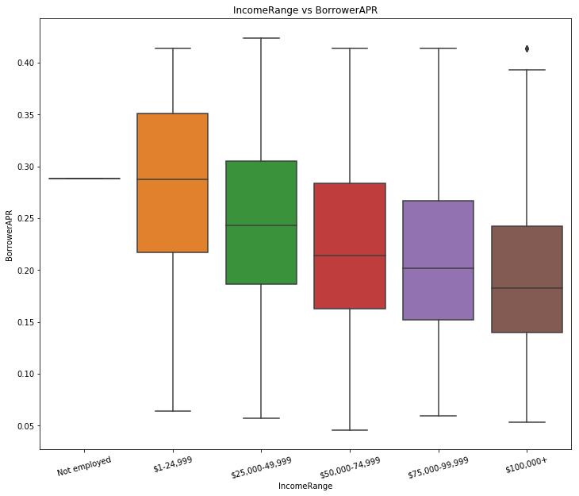

## Relationship between BorrowerAPR and LoanStatus

> I have also noticed that theres a relationship between Loans that went into arrears and the interest rate. The higher the interest rate, the higher the chance of the loanee defaulting or going into arrears.

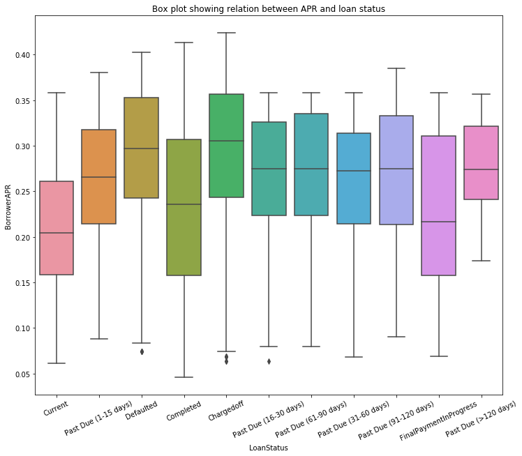

## Relationship between both Income Range and ProsperRating

> I have noticed that Income Range is a minor factor contributing to Borrowing APR and the major factor is the customers Prosper Rating . The lowest ProsperRating which is 'HR' seems to have the highest BorrowerAPR while the the rating'AA' seems to have the lowest BorrowerAPR. This is expected as the better the rating, the less risk the Loanee would be.

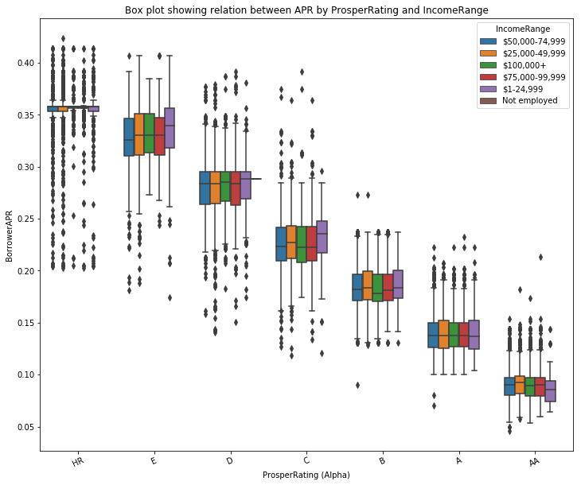

### Submission

   ```
   zip -r my_project.zip .
   ```